# Titanic: Data Analysis with Visualizations

```
Udacity - Intro to Data Analysis
Udacity - Data Analyst Nanodegree Program
Author: Leonardo Simões
```

## Introduction

This is a project for the Intro to Data Analysis course and for the Nanodegree program Data Analyst, both from Udacity. The main objective is to use well-polished data visualizations to convey ideas and confirm the information obtained. The other steps of the data analysis process are also carried out in this project, but only in a necessary and not very detailed way.

The dataset is the one suggested at the end of the Introduction to Data Analysis course, but it also satisfies the conditions imposed on the respective task of the data analyst in the Nanodegree program. This dataset is a large portion of Titanic passengers and was made available by Kaggle. Data analysis is focused on the characteristics of Titanic passengers.

Features:

- `Survived`: Survival (0 = No, 1 = Yes)
- `Pclass`: Ticket class (1 = 1st, 2 = 2nd, 3 = 3rd)
- `Name`: name of passenger
- `Sex`: male or female
- `Age`: Age in years
- `Sibsp`: # of siblings / spouses aboard the Titanic
- `Parch`: # of parents / children aboard the Titanic
- `Ticket`: Ticket number
- `Fare`: Passenger fare
- `Cabin`: Cabin number
- `Embarked`: Port of Embarkation ('S' = Southampton, 'C' = Cherbourg, 'Q' = Queenstown)

Survival, Ticket class, Sex, Age, Sibsp, Parch, Fare and Embarked features will be used in the analysis.

The Name, Ticket number and Cabin number features will not be used in the analysis.

## Exploratory analysis

This analysis, unlike the standard, will not answer previously asked and well-established questions. This analysis will be done by observing the values and relationships between the variables, and then with values and visualizations, some observations will be made. First, a one-dimensional exploratory analysis will be carried out, and then a two-dimensional analysis, and then a multidimensional analysis.

- Descriptive statistics of numerical features:

```python
df.describe()
```

|  | PassengerId | Survived | Pclass | Age | SibSp | Parch | Fare |
| --- | --- | --- | --- | --- | --- | --- | --- |
| count | 891.000000 | 891.000000 | 891.000000 | 891.000000 | 891.000000 | 891.000000 | 891.000000 |
| mean | 446.000000 | 0.383838 | 2.308642 | 29.699118 | 0.523008 | 0.381594 | 32.204208 |
| std | 257.353842 | 0.486592 | 0.836071 | 13.002015 | 1.102743 | 0.806057 | 49.693429 |
| min | 1.000000 | 0.000000 | 1.000000 | 0.420000 | 0.000000 | 0.000000 | 0.000000 |
| 25% | 223.500000 | 0.000000 | 2.000000 | 22.000000 | 0.000000 | 0.000000 | 7.910400 |
| 50% | 446.000000 | 0.000000 | 3.000000 | 29.699118 | 0.000000 | 0.000000 | 14.454200 |
| 75% | 668.500000 | 1.000000 | 3.000000 | 35.000000 | 1.000000 | 0.000000 | 31.000000 |
| max | 891.000000 | 1.000000 | 3.000000 | 80.000000 | 8.000000 | 6.000000 | 512.329200 |

- Proportion of survivors:

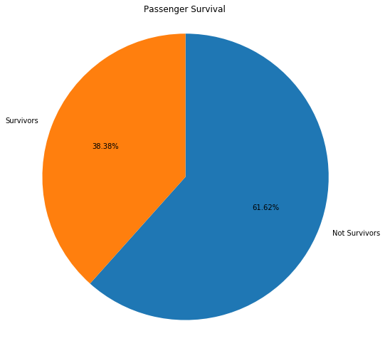

```python
#Plot of pie chart of survivors
plt.figure(figsize=[11.69,8.27]);
plt.pie(survived_counts, labels=survived_counts.index,
        startangle=90,counterclock=False, autopct='%1.2f%%');
plt.axis('square');
plt.title('Passenger Survival');
```

Of the 891 passengers, 549 (61.62%) did not survive and 342 (38.38%) survived.

- Count of passengers by sex:

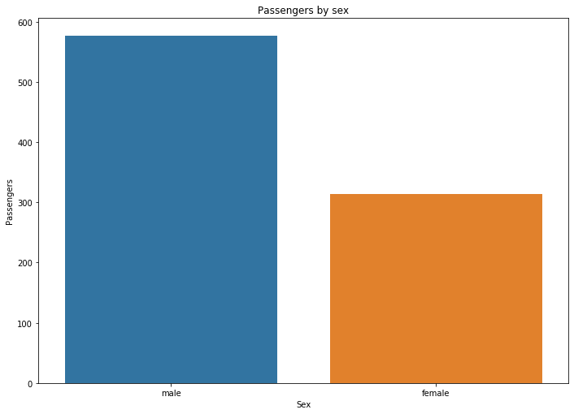

```python
#Plot of passenger bar graph by Sex
plt.figure(figsize=[11.69,8.27]);
sns.countplot(df['Sex']);
plt.title('Passengers by sex');
plt.ylabel('Passengers');
plt.xlabel('Sex');
```

- Age and Survived:

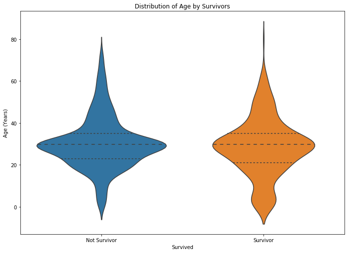

```python
#ViolinPlot of the distribtion of Age by Survivors
plt.figure(figsize=[11.69,8.27]);
ax = sns.violinplot(data=df, x='Survived', y='Age', inner='quartile');
ax.set_xticklabels(['Not Survivor', 'Survivor']);
ax.set_title('Distribution of Age by Survivors');
ax.set_ylabel('Age (Years)');
```

- Age and Sex:

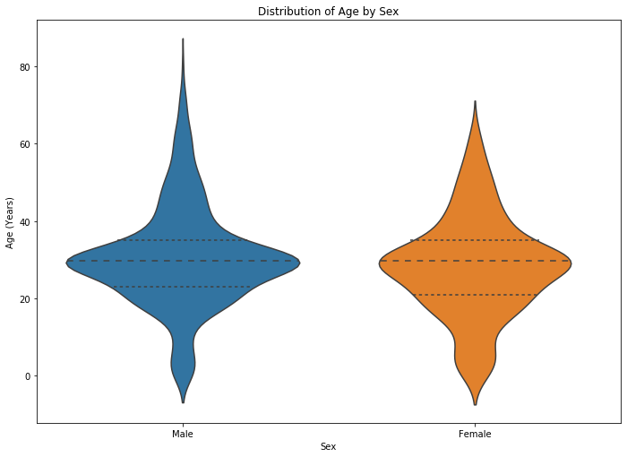

```python
#ViolinPlot of the distribtion of Age by Sex
plt.figure(figsize=[11.69,8.27]);
ax = sns.violinplot(data=df, x='Sex', y='Age', inner='quartile');
ax.set_xticklabels(['Male', 'Female']);
ax.set_title('Distribution of Age by Sex');
ax.set_ylabel('Age (Years)');
```

- Mean age by Survived and Sex:

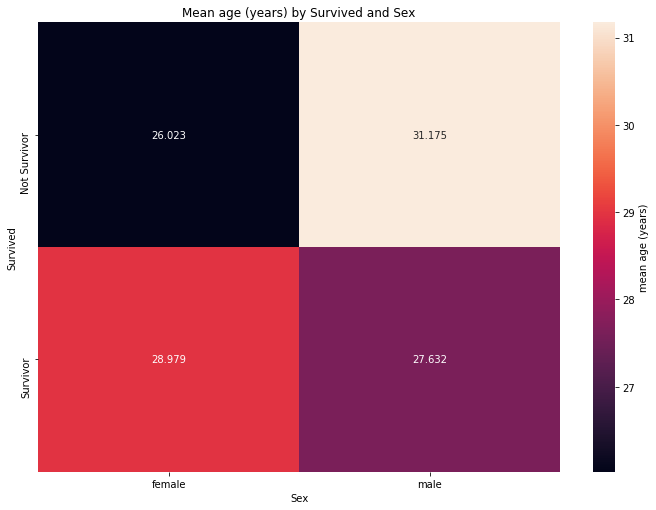

```python
#Plot of heatmap using average Age by Sex and by Survived
plt.figure(figsize=[11.69,8.27]);
cat_means = df.groupby(['Sex', 'Survived']).mean()['Age']
cat_means = cat_means.reset_index(name = 'Age_avg');
cat_means = cat_means.pivot(index = 'Survived', columns = 'Sex',
                            values = 'Age_avg');
ax = sns.heatmap(cat_means, annot = True, fmt = '.3f',
                   cbar_kws = {'label' : 'mean age (years)'},
                 yticklabels=['Not Survivor', 'Survivor']);
ax.set_title('Mean age (years) by Survived and Sex');
```

The average age of men and women for survivors and non-survivors varies up to just 5 years. Older women seem to have survived longer than younger women. With the men, it was the opposite, the younger ones seem to have survived longer than the older ones.

### References

UDACITY - Intro to Data Analysis: https://www.udacity.com/course/intro-to-data-analysis--ud170

UDACITY - Data Analyst Nanodegree Program: https://www.udacity.com/course/data-analyst-nanodegree--nd002

KAGGLE - https://www.kaggle.com/c/titanic/data